# Analysis - SMC Paper Structured

Tom Offrede

2023-01-27

# Confederate

## Read Speech

### Cycle Durations

```r
dat <- brm %>%
  filter(Role=="Confederate", grepl("Read", Task))
```

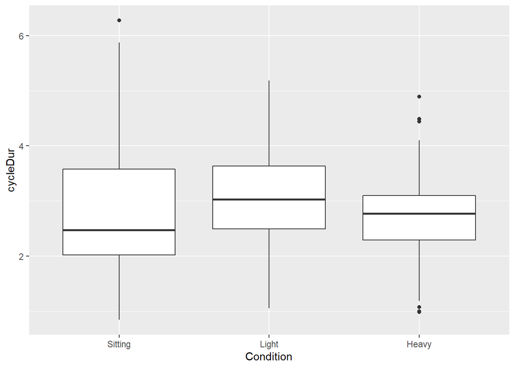

```r
ggplot(dat, aes(Condition, cycleDur))+
  geom_boxplot()
```

- Difference only between Light and the other conditions, but no difference between Sitting and Heavy. So there is probably noise in the data and we can consider that there was no effect of condition on breathing cycle duration.

```r
# dat$Condition <- relevel(dat$Condition, ref="Light")
summary(b1 <- lm(cycleDur ~ Condition, dat))
```

```
##
## Call:
## lm(formula = cycleDur ~ Condition, data = dat)
##
## Residuals:
##     Min      1Q  Median      3Q     Max
## -2.0035 -0.5572 -0.0023  0.4849  3.5504
##
## Coefficients:
##                Estimate Std. Error t value Pr(>|t|)
## (Intercept)     2.72304    0.07969  34.172  < 2e-16 ***
## ConditionLight  0.34143    0.11269   3.030  0.00261 **
## ConditionHeavy -0.02070    0.10703  -0.193  0.84672
## ---
## Signif. codes:  0 '***' 0.001 '**' 0.01 '*' 0.05 '.' 0.1 ' ' 1
##
## Residual standard error: 0.8838 on 396 degrees of freedom
## Multiple R-squared:  0.03321,    Adjusted R-squared:  0.02833
## F-statistic: 6.802 on 2 and 396 DF,  p-value: 0.001246
```

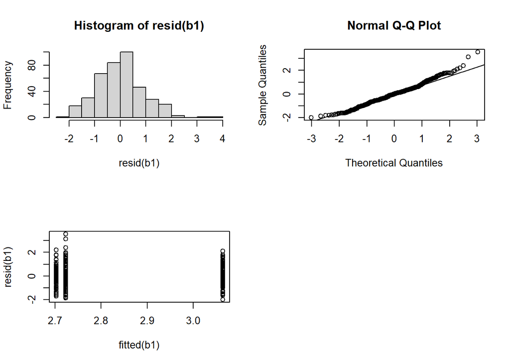

```r
par(mfrow=c(2, 2))
hist(resid(b1))
qqnorm(resid(b1));qqline(resid(b1))
plot(fitted(b1), resid(b1))
```

### Inhalation Amplitude

```r
dat <- brm %>%
  filter(Role=="Confederate", grepl("Read", Task))
```

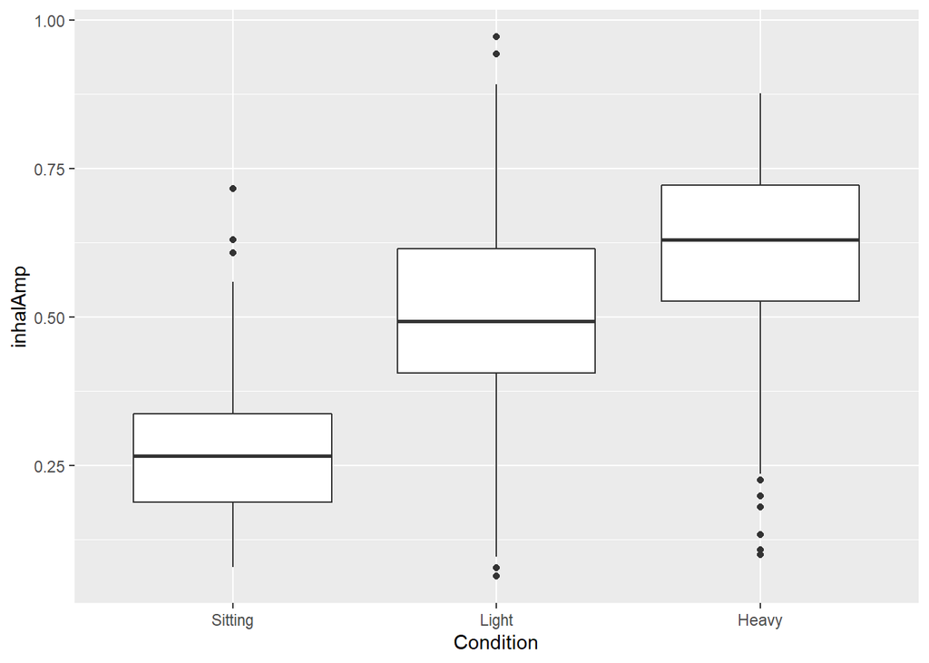

```r
ggplot(dat, aes(Condition, inhalAmp))+
  geom_boxplot()
```

- Inhalation amplitude got higher with physical effort.

```r
# dat$Condition <- relevel(dat$Condition, ref="Light")
summary(d1 <- lm(inhalAmp ~ Condition, dat))
```

```
##
## Call:
## lm(formula = inhalAmp ~ Condition, data = dat)
##
## Residuals:
##      Min       1Q   Median       3Q      Max
## -0.50546 -0.09092 -0.00563  0.10216  0.46443
##
## Coefficients:
##                Estimate Std. Error t value Pr(>|t|)
## (Intercept)     0.28263    0.01412   20.01   <2e-16 ***
## ConditionLight  0.22477    0.01997   11.26   <2e-16 ***
## ConditionHeavy  0.32190    0.01897   16.97   <2e-16 ***
## ---
## Signif. codes:  0 '***' 0.001 '**' 0.01 '*' 0.05 '.' 0.1 ' ' 1
##
## Residual standard error: 0.1566 on 396 degrees of freedom
## Multiple R-squared:  0.4273, Adjusted R-squared:  0.4244
## F-statistic: 147.7 on 2 and 396 DF,  p-value: < 2.2e-16
```

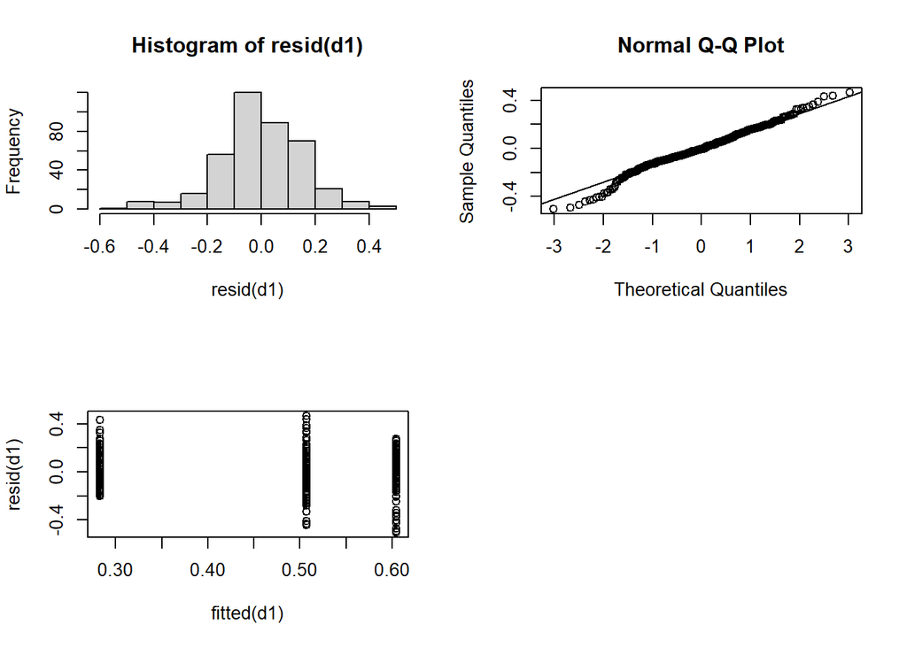

```r
par(mfrow=c(2, 2))
hist(resid(d1))
qqnorm(resid(d1));qqline(resid(d1))
plot(fitted(d1), resid(d1))
```

### F0

```r
dat <- frb %>%
  filter(grepl("Read", Task), Speaker == "Confederate")
```

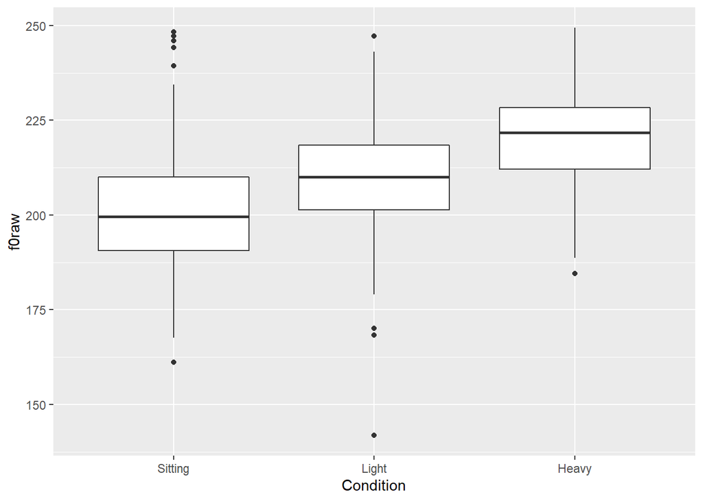

```r
ggplot(dat, aes(Condition, f0raw))+
  geom_boxplot()
```

- F0 got higher with physical effort.

```r
# dat$Condition <- relevel(dat$Condition, ref="Light")
summary(f1 <- lm(f0raw ~ Condition, dat))
```

```
##
## Call:
## lm(formula = f0raw ~ Condition, data = dat)
##
## Residuals:
##     Min      1Q  Median      3Q     Max
## -67.490  -9.331  -0.066   8.915  47.378
##
## Coefficients:
##                Estimate Std. Error t value Pr(>|t|)
## (Intercept)    200.9550     0.7699 261.001  < 2e-16 ***
## ConditionLight   8.3352     1.1273   7.394 2.97e-13 ***
## ConditionHeavy  19.4587     1.1129  17.485  < 2e-16 ***
## ---
## Signif. codes:  0 '***' 0.001 '**' 0.01 '*' 0.05 '.' 0.1 ' ' 1
##
## Residual standard error: 14.73 on 1019 degrees of freedom
## Multiple R-squared:  0.2313, Adjusted R-squared:  0.2298
## F-statistic: 153.3 on 2 and 1019 DF,  p-value: < 2.2e-16
```

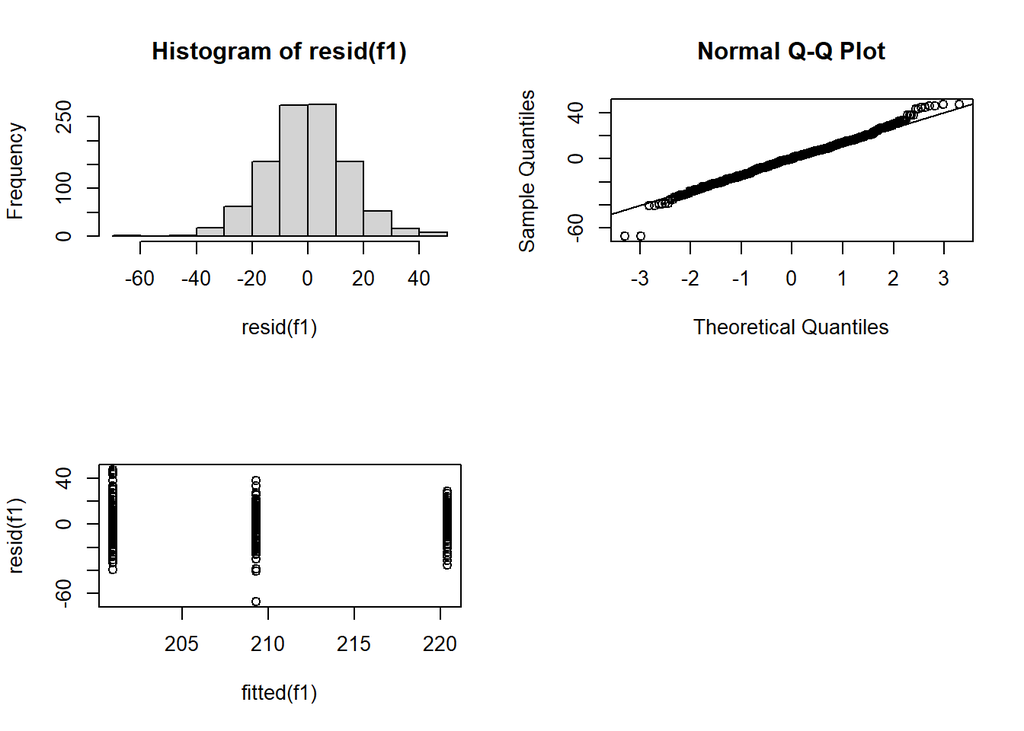

```r
par(mfrow=c(2, 2))
hist(resid(f1))
qqnorm(resid(f1));qqline(resid(f1))
plot(fitted(f1), resid(f1))
```

## Free Speech

### Cycle Durations

```r
dat <- brm %>%
  filter(Role=="Confederate", Task=="Free")
```

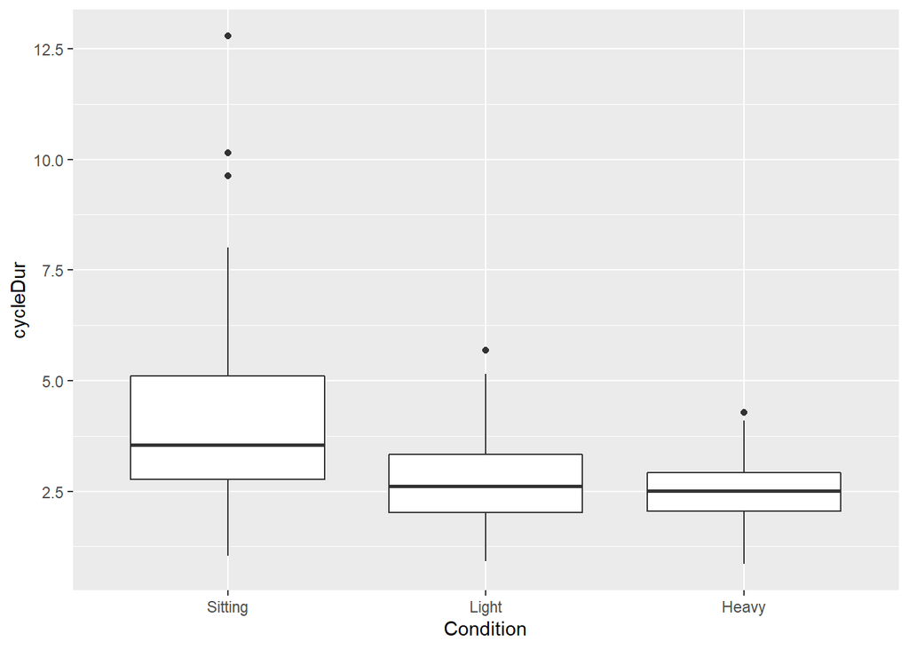

```r
ggplot(dat, aes(Condition, cycleDur))+
  geom_boxplot()
```

- Cycles are shorter during biking than during sitting. There’s a trend of Heavy being shorter than Light, but it doesn’t reach significance.

```r
# dat$Condition <- relevel(dat$Condition, ref="Light")
summary(b1 <- lm(cycleDur ~ Condition, dat))
```

```
##
## Call:
## lm(formula = cycleDur ~ Condition, data = dat)
##
## Residuals:
##     Min      1Q  Median      3Q     Max
## -3.0089 -0.7171 -0.0978  0.5891  8.7333
##
## Coefficients:
##                Estimate Std. Error t value Pr(>|t|)
## (Intercept)      4.0524     0.1039   39.01   <2e-16 ***
## ConditionLight  -1.3943     0.1360  -10.25   <2e-16 ***
## ConditionHeavy  -1.5692     0.1402  -11.19   <2e-16 ***
## ---
## Signif. codes:  0 '***' 0.001 '**' 0.01 '*' 0.05 '.' 0.1 ' ' 1
##
## Residual standard error: 1.238 on 511 degrees of freedom
## Multiple R-squared:  0.2244, Adjusted R-squared:  0.2214
## F-statistic: 73.93 on 2 and 511 DF,  p-value: < 2.2e-16
```

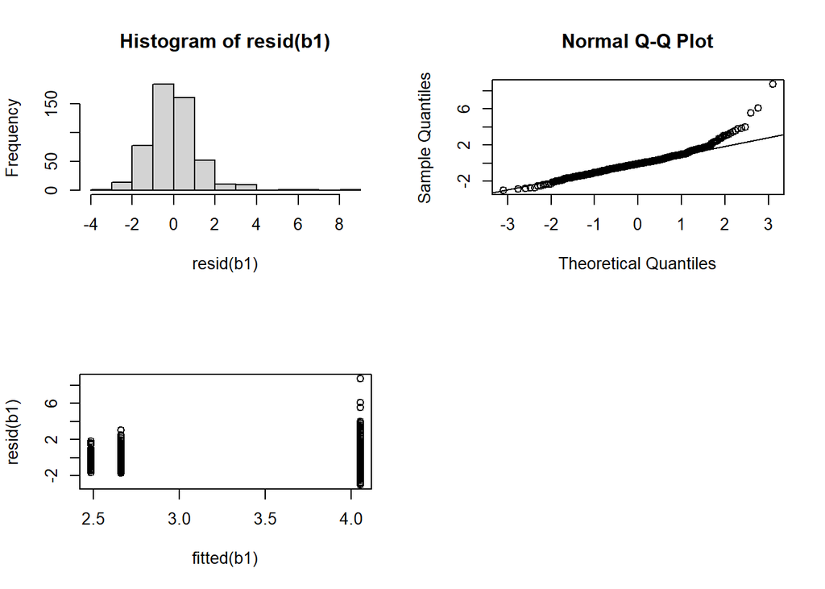

```r
par(mfrow=c(2, 2))
hist(resid(b1))
qqnorm(resid(b1));qqline(resid(b1))
plot(fitted(b1), resid(b1))
```

### Inhalation Amplitude

```r
dat <- brm %>%
  filter(Role=="Confederate", Task=="Free")
```

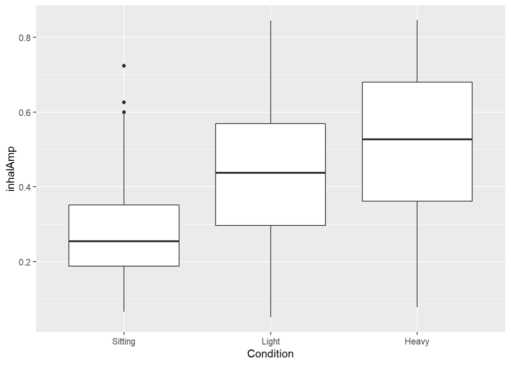

```r
ggplot(dat, aes(Condition, inhalAmp))+
  geom_boxplot()
```

- Inhalation amplitude gets larger with physical effort.

```r
# dat$Condition <- relevel(dat$Condition, ref="Light")
summary(d1 <- lm(inhalAmp ~ Condition, dat))
```

```
##
## Call:
## lm(formula = inhalAmp ~ Condition, data = dat)
##
## Residuals:
##      Min       1Q   Median       3Q      Max
## -0.42765 -0.12191 -0.00077  0.13229  0.43873
##
## Coefficients:
##                Estimate Std. Error t value Pr(>|t|)
## (Intercept)     0.28452    0.01469  19.372  < 2e-16 ***
## ConditionLight  0.14821    0.01923   7.709 6.68e-14 ***
## ConditionHeavy  0.22088    0.01982  11.145  < 2e-16 ***
## ---
## Signif. codes:  0 '***' 0.001 '**' 0.01 '*' 0.05 '.' 0.1 ' ' 1
##
## Residual standard error: 0.175 on 511 degrees of freedom
## Multiple R-squared:  0.1992, Adjusted R-squared:  0.196
## F-statistic: 63.54 on 2 and 511 DF,  p-value: < 2.2e-16
```

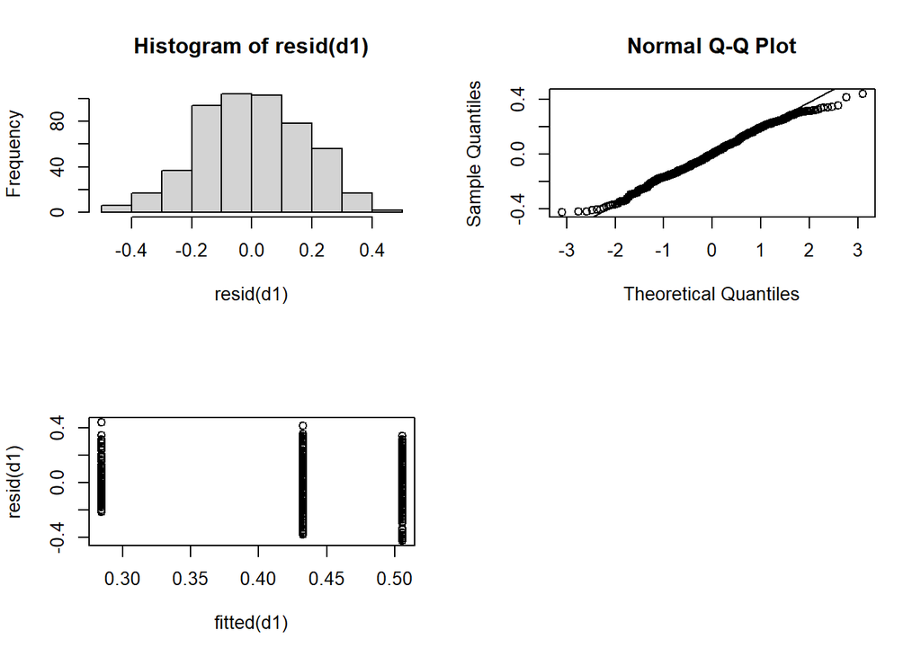

```r
par(mfrow=c(2, 2))
hist(resid(d1))
qqnorm(resid(d1));qqline(resid(d1))
plot(fitted(d1), resid(d1))
```

### F0

```r
dat <- fsm %>%
  filter(Task == "Free", Speaker == "Confederate")
```

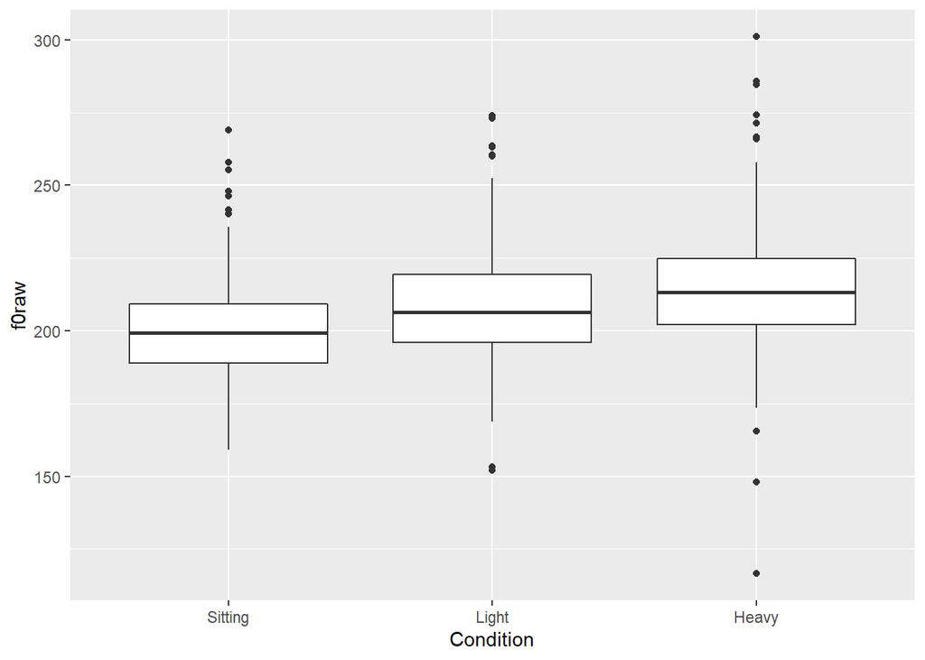

```r
ggplot(dat, aes(Condition, f0raw))+
  geom_boxplot()
```

- F0 increased with physical effort.

```r
# dat$Condition <- relevel(dat$Condition, ref="Light")
summary(m1 <- lm(f0raw ~ Condition, dat))
```

```
##
## Call:
## lm(formula = f0raw ~ Condition, data = dat)
##
## Residuals:
##     Min      1Q  Median      3Q     Max
## -97.664 -11.945  -1.536  10.085  86.936
##
## Coefficients:
##                Estimate Std. Error t value Pr(>|t|)
## (Intercept)     200.149      1.126 177.708  < 2e-16 ***
## ConditionLight    8.359      1.564   5.345 1.16e-07 ***
## ConditionHeavy   14.015      1.612   8.695  < 2e-16 ***
## ---
## Signif. codes:  0 '***' 0.001 '**' 0.01 '*' 0.05 '.' 0.1 ' ' 1
##
## Residual standard error: 18.95 on 855 degrees of freedom
##   (29 Beobachtungen als fehlend gelöscht)
## Multiple R-squared:  0.08249,    Adjusted R-squared:  0.08034
## F-statistic: 38.43 on 2 and 855 DF,  p-value: < 2.2e-16
```

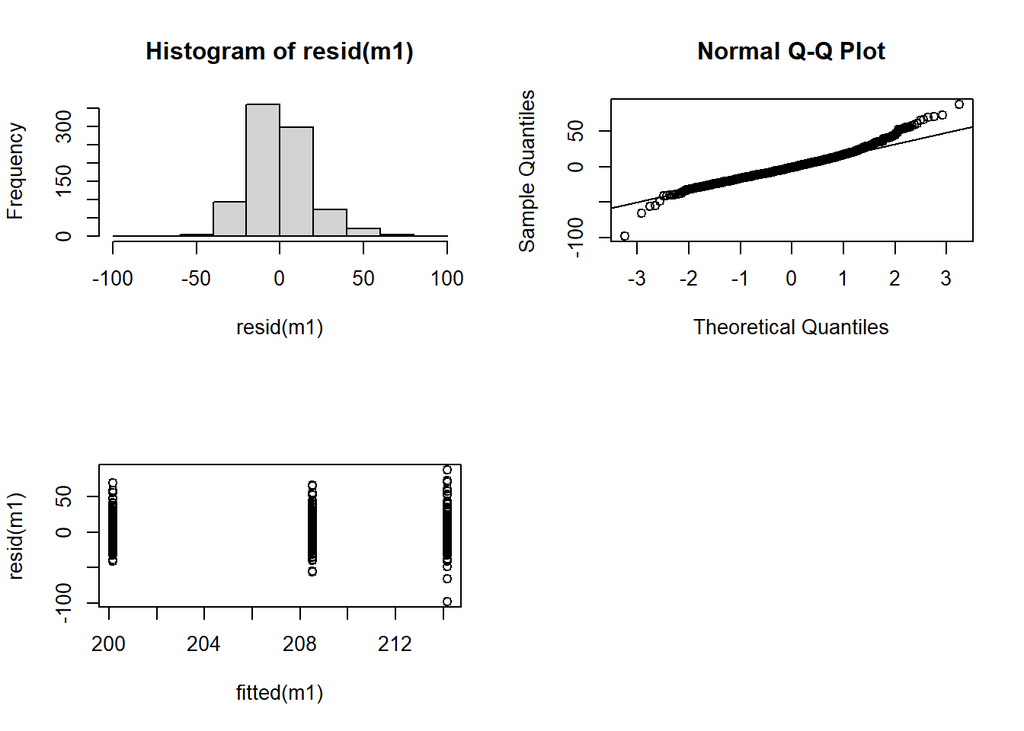

```r
par(mfrow=c(2, 2))
hist(resid(m1))
qqnorm(resid(m1));qqline(resid(m1))
plot(fitted(m1), resid(m1))
```

# 0 - Breathing. Do people adapt their breathing to a confederate who is moving under different levels of physical effort when both of them are silent?

## Cycle Duration

```r
dat <- brm %>%
  filter(Role=="Participant", act=="watching")
```

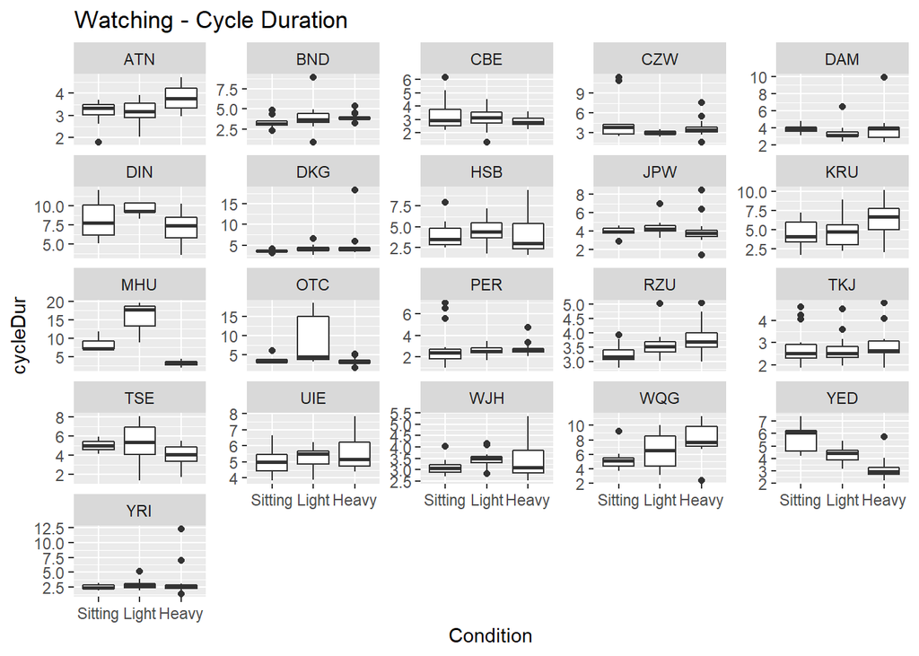

```r
# Individual effects
ggplot(dat, aes(Condition, cycleDur))+
  geom_boxplot()+
  facet_wrap(~Speaker, scales="free_y")+
  ggtitle("Watching - Cycle Duration")
```

```r
ggsave(paste0(folderInd, "Watching-CycleDur.png"), width = 3000, height=3000, units="px")
```

A few participants behaved in opposite ways.

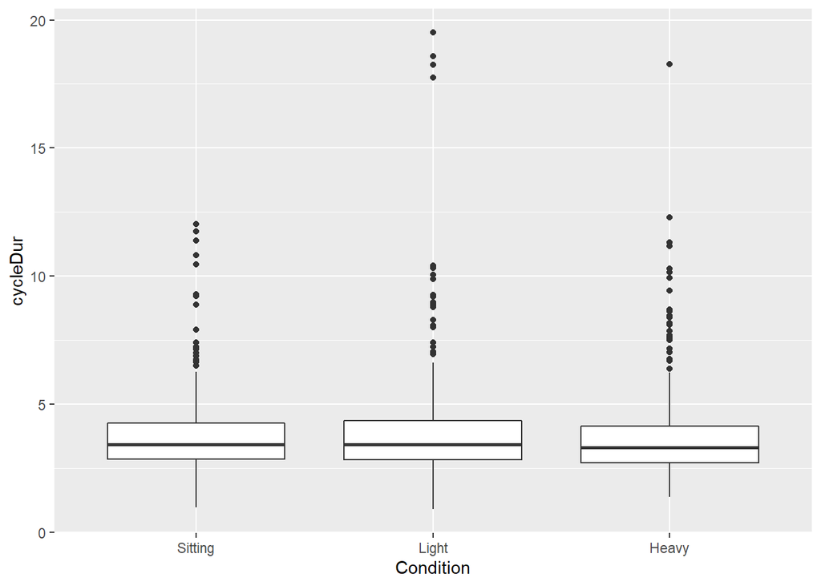

```r
ggplot(dat, aes(Condition, cycleDur))+
  geom_boxplot()
```

No effect of condition on cycle duration while watching.

```r
summary(b1 <- lmer(cycleDur ~ Condition + (1+Condition| Speaker), dat))
```

```
## Linear mixed model fit by REML ['lmerMod']
## Formula: cycleDur ~ Condition + (1 + Condition | Speaker)
##    Data: dat
##
## REML criterion at convergence: 3167.4
##
## Scaled residuals:
##     Min      1Q  Median      3Q     Max
## -3.8396 -0.3743 -0.1188  0.1752  8.7076
##
## Random effects:
##  Groups   Name           Variance Std.Dev. Corr
##  Speaker  (Intercept)    2.251    1.500
##           ConditionLight 3.092    1.758     0.54
##           ConditionHeavy 2.056    1.434    -0.60 -0.54
##  Residual                2.237    1.496
## Number of obs: 827, groups:  Speaker, 21
##
## Fixed effects:
##                Estimate Std. Error t value
## (Intercept)     4.25078    0.34106  12.463
## ConditionLight  0.68254    0.40751   1.675
## ConditionHeavy -0.04326    0.33971  -0.127
##
## Correlation of Fixed Effects:
##             (Intr) CndtnL
## ConditnLght  0.421
## ConditinHvy -0.606 -0.404
```

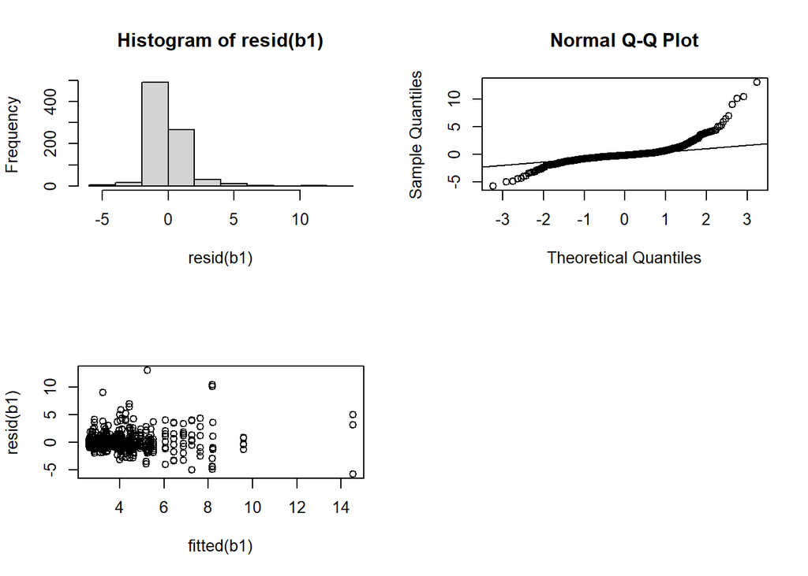

```r
par(mfrow=c(2, 2))
hist(resid(b1))
qqnorm(resid(b1));qqline(resid(b1))
plot(fitted(b1), resid(b1))
```

## Inhalation Amplitude

```r
dat <- brm %>%
  filter(Role=="Participant", act=="watching")
```

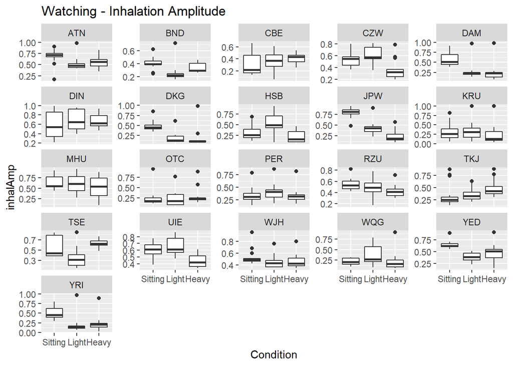

```r
# Individual effects
ggplot(dat, aes(Condition, inhalAmp))+
  geom_boxplot()+
  facet_wrap(~Speaker, scales="free_y")+
  ggtitle("Watching - Inhalation Amplitude")
```

```r
ggsave(paste0(folderInd, "Watching-InhalAmp.png"), width = 3000, height=3000, units="px")
```

Again, a few participants behaved in opposite ways.

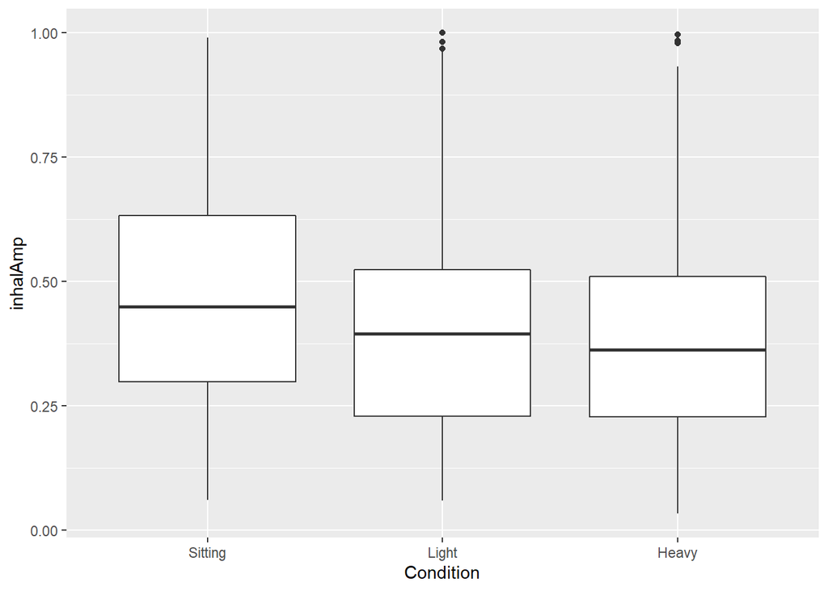

```r
ggplot(dat, aes(Condition, inhalAmp))+
  geom_boxplot()
```

Lower inhalation amplitude during Heavy than Sitting, with Light in between.

```r
summary(b1 <- lmer(inhalAmp ~ Condition + (1+Condition| Speaker), dat))
```

```
## Linear mixed model fit by REML ['lmerMod']
## Formula: inhalAmp ~ Condition + (1 + Condition | Speaker)
##    Data: dat
##
## REML criterion at convergence: -440
##
## Scaled residuals:
##     Min      1Q  Median      3Q     Max
## -2.9346 -0.5829 -0.1879  0.3728  4.5091
##
## Random effects:
##  Groups   Name           Variance Std.Dev. Corr
##  Speaker  (Intercept)    0.02286  0.1512
##           ConditionLight 0.02446  0.1564   -0.61
##           ConditionHeavy 0.02354  0.1534   -0.63  0.71
##  Residual                0.02897  0.1702
## Number of obs: 827, groups:  Speaker, 21
##
## Fixed effects:
##                Estimate Std. Error t value
## (Intercept)     0.48451    0.03477  13.933
## ConditionLight -0.07083    0.03755  -1.886
## ConditionHeavy -0.09846    0.03674  -2.680
##
## Correlation of Fixed Effects:
##             (Intr) CndtnL
## ConditnLght -0.617
## ConditinHvy -0.636  0.678
```

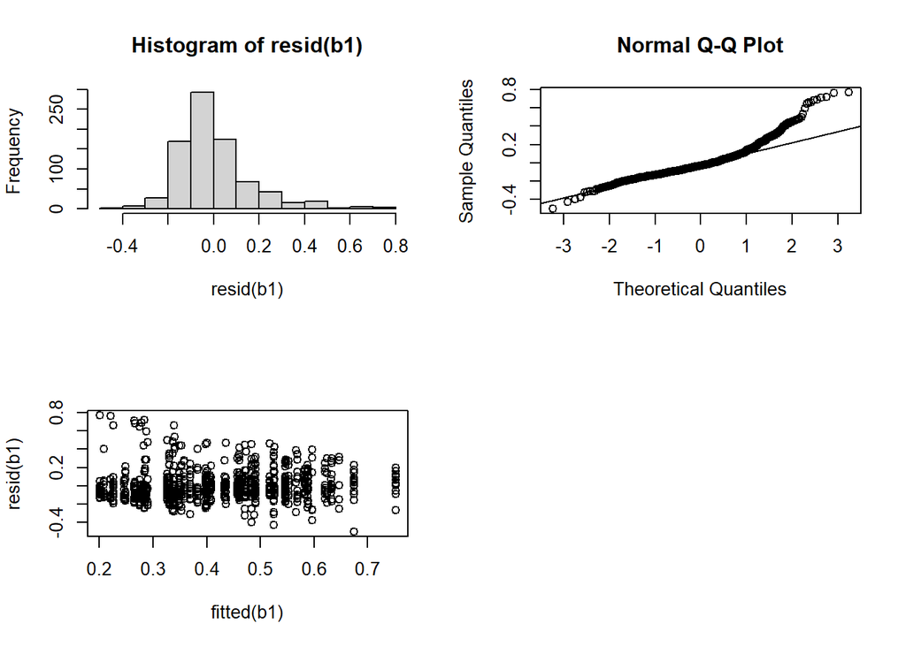

```r
par(mfrow=c(2, 2))
hist(resid(b1))
qqnorm(resid(b1));qqline(resid(b1))
plot(fitted(b1), resid(b1))
```

# 1 - Breathing. Is there a difference in respiratory behavior when people talk alone or in an interaction?

## Solo read speech

### Cycle Duration

```r
dat <- brm %>%
  filter(Role=="Participant", Task%in%c("ReadAlone", "ReadBaseline"))
```

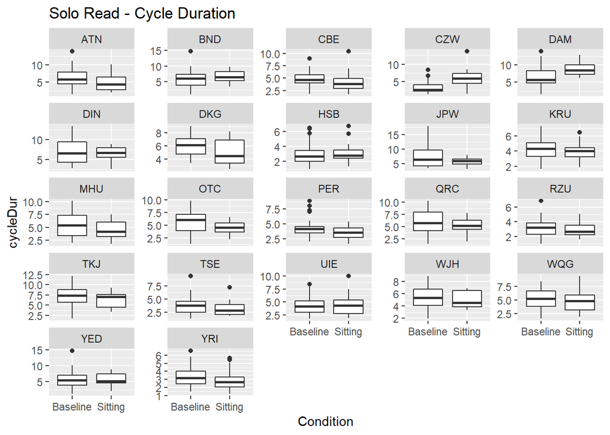

```r
# Individual effects
ggplot(dat %>% filter(Condition %in% c("Baseline", "Sitting")), aes(Condition, cycleDur))+
  geom_boxplot()+
  facet_wrap(~Speaker, scales="free_y")+
  ggtitle("Solo Read - Cycle Duration")
```

```r
ggsave(paste0(folderInd, "SoloRead-CycleDur-BaselineInteraction.png"), width = 3000, height=3000, units="px")
```

Many participants seemed to have shorter cycles during Sitting than during Baseline. A few of them had clearly longer cycles during Sitting than during Baseline.

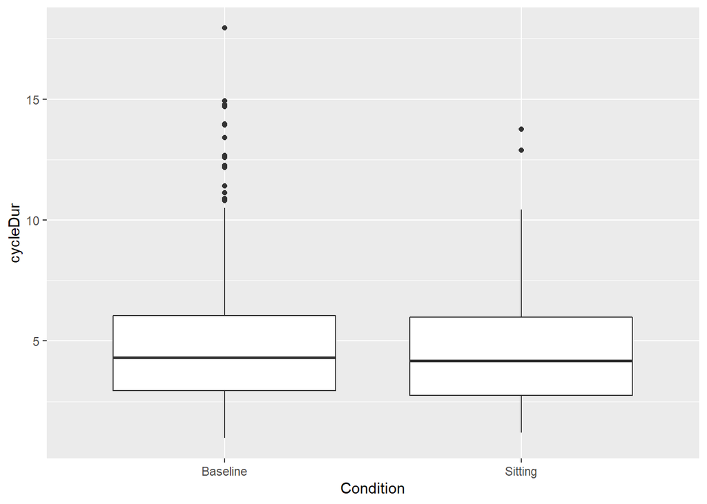

```r
ggplot(dat %>% filter(Condition %in% c("Baseline", "Sitting")), aes(Condition, cycleDur))+
  geom_boxplot()
```

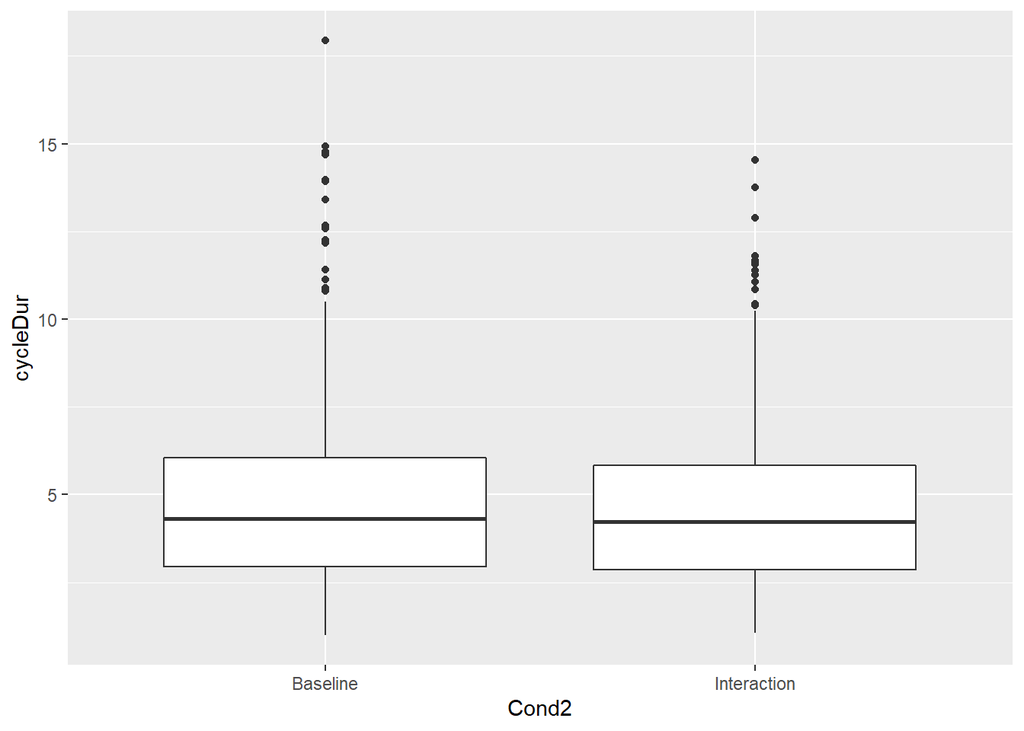

```r
ggplot(dat, aes(Cond2, cycleDur))+
  geom_boxplot()
```

- Cycle duration doesn’t change between Baseline and Sitting or Baseline and Interaction during solo read speech.

```r
summary(b1 <- lmer(cycleDur ~ Condition + (1+Condition| Speaker), dat %>% filter(Condition %in% c("Baseline", "Sitting"))))
```

```
## Linear mixed model fit by REML ['lmerMod']
## Formula: cycleDur ~ Condition + (1 + Condition | Speaker)
##    Data: dat %>% filter(Condition %in% c("Baseline", "Sitting"))
##
## REML criterion at convergence: 4530.7
##
## Scaled residuals:
##     Min      1Q  Median      3Q     Max
## -2.5780 -0.6375 -0.0928  0.5348  5.3037
##
## Random effects:
##  Groups   Name             Variance Std.Dev. Corr
##  Speaker  (Intercept)      1.7109   1.3080
##           ConditionSitting 0.4963   0.7045   -0.36
##  Residual                  4.1099   2.0273
## Number of obs: 1047, groups:  Speaker, 22
##
## Fixed effects:
##                  Estimate Std. Error t value
## (Intercept)        5.1550     0.2893  17.819
## ConditionSitting  -0.2768     0.2090  -1.324
##
## Correlation of Fixed Effects:
##             (Intr)
## CondtnSttng -0.348
```

```r
summary(b1 <- lmer(cycleDur ~ Cond2 + (1+Cond2| Speaker), dat))
```

```
## Linear mixed model fit by REML ['lmerMod']
## Formula: cycleDur ~ Cond2 + (1 + Cond2 | Speaker)
##    Data: dat
##
## REML criterion at convergence: 6856.3
##
## Scaled residuals:
##     Min      1Q  Median      3Q     Max
## -2.7645 -0.6610 -0.0959  0.5289  5.5080
##
## Random effects:
##  Groups   Name             Variance Std.Dev. Corr
##  Speaker  (Intercept)      1.7221   1.3123
##           Cond2Interaction 0.1685   0.4104   -0.42
##  Residual                  3.9449   1.9862
## Number of obs: 1608, groups:  Speaker, 22
##
## Fixed effects:
##                  Estimate Std. Error t value
## (Intercept)        5.1526     0.2896  17.792
## Cond2Interaction  -0.2537     0.1340  -1.893
##
## Correlation of Fixed Effects:
##             (Intr)
## Cnd2Intrctn -0.408
```

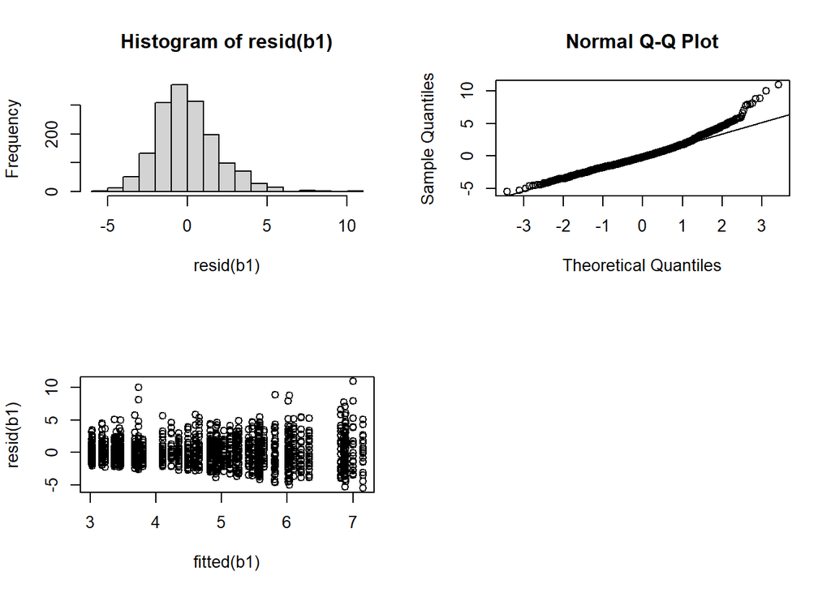

```r
par(mfrow=c(2, 2))
hist(resid(b1))
qqnorm(resid(b1));qqline(resid(b1))
plot(fitted(b1), resid(b1))
```

### Inhalation Amplitude

```r
dat <- brm %>%
  filter(Role=="Participant", Task%in%c("ReadAlone", "ReadBaseline"))
```

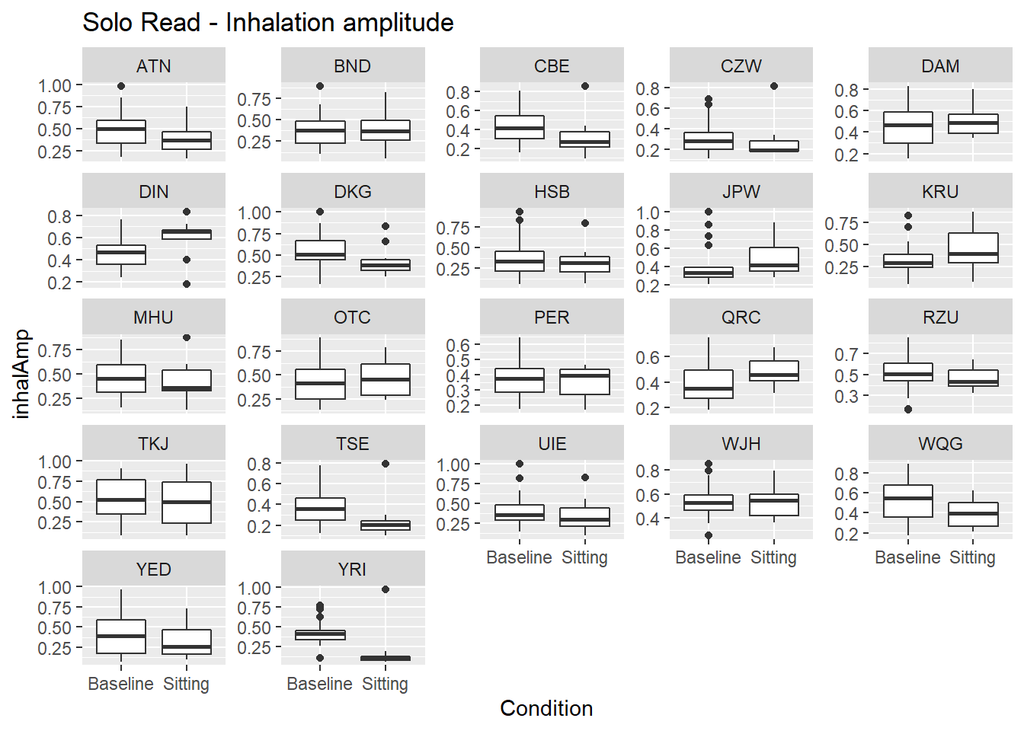

```r
ggplot(dat %>% filter(Condition %in% c("Baseline", "Sitting")), aes(Condition, inhalAmp))+
  geom_boxplot()+
  facet_wrap(~Speaker, scales="free_y")+
  ggtitle("Solo Read - Inhalation amplitude")
```

```r
ggsave(paste0(folderInd, "SoloRead-InhalAmp-BaselineInteraction.png"), width = 3000, height=3000, units="px")
```

Some participants didn’t change. Half of them seemed to have lower inhalation amplitudes during Sitting, and around 5, the opposite.

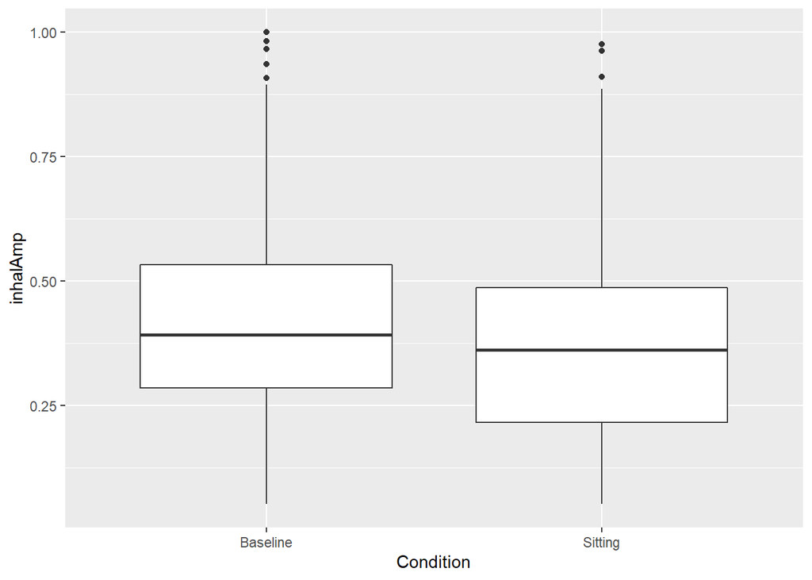

```r
ggplot(dat %>% filter(Condition %in% c("Baseline", "Sitting")), aes(Condition, inhalAmp))+
  geom_boxplot()
```

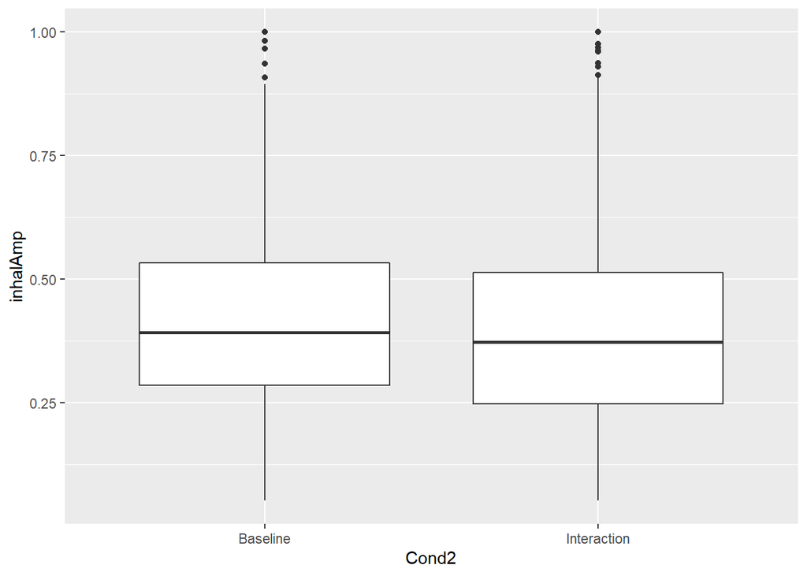

```r
ggplot(dat, aes(Cond2, inhalAmp))+
  geom_boxplot()
```

- Inhalation amplitude doesn’t change between Baseline and Sitting or Baseline and Interaction during solo read speech.

```r
summary(b1 <- lmer(inhalAmp ~ Condition + (1+Condition| Speaker), dat %>% filter(Condition %in% c("Baseline", "Sitting"))))
```

```
## Linear mixed model fit by REML ['lmerMod']
## Formula: inhalAmp ~ Condition + (1 + Condition | Speaker)
##    Data: dat %>% filter(Condition %in% c("Baseline", "Sitting"))
##
## REML criterion at convergence: -573.8
##
## Scaled residuals:
##     Min      1Q  Median      3Q     Max
## -2.4159 -0.6902 -0.1222  0.5684  4.3780
##
## Random effects:
##  Groups   Name             Variance Std.Dev. Corr
##  Speaker  (Intercept)      0.004047 0.06362
##           ConditionSitting 0.006212 0.07882  -0.10
##  Residual                  0.031493 0.17746
## Number of obs: 1047, groups:  Speaker, 22
##
## Fixed effects:
##                  Estimate Std. Error t value
## (Intercept)       0.43354    0.01513  28.654
## ConditionSitting -0.03690    0.02111  -1.748
##
## Correlation of Fixed Effects:
##             (Intr)
## CondtnSttng -0.208
```

```r
summary(b1 <- lmer(inhalAmp ~ Cond2 + (1+Cond2| Speaker), dat))
```

```
## Linear mixed model fit by REML ['lmerMod']
## Formula: inhalAmp ~ Cond2 + (1 + Cond2 | Speaker)
##    Data: dat
##
## REML criterion at convergence: -893.5
##
## Scaled residuals:
##     Min      1Q  Median      3Q     Max
## -2.5475 -0.6843 -0.1267  0.5689  3.6190
##
## Random effects:
##  Groups   Name             Variance Std.Dev. Corr
##  Speaker  (Intercept)      0.004040 0.06356
##           Cond2Interaction 0.002009 0.04482  0.03
##  Residual                  0.031967 0.17879
## Number of obs: 1608, groups:  Speaker, 22
##
## Fixed effects:
##                  Estimate Std. Error t value
## (Intercept)       0.43452    0.01512  28.737
## Cond2Interaction -0.02487    0.01324  -1.879
##
## Correlation of Fixed Effects:
##             (Intr)
## Cnd2Intrctn -0.202
```

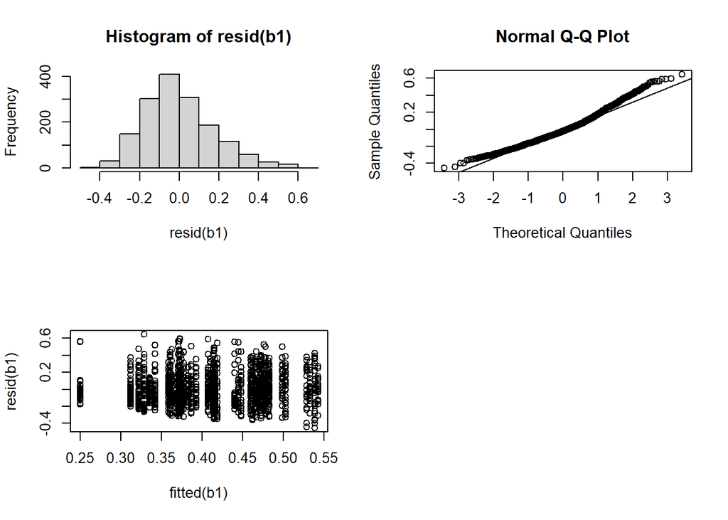

```r
par(mfrow=c(2, 2))
hist(resid(b1))
qqnorm(resid(b1));qqline(resid(b1))
plot(fitted(b1), resid(b1))
```

## Solo spontaneous speech

### Cycle Duration

```r
dat <- brm %>%
  filter(Role=="Participant", Task=="Free", act=="speaking")
```

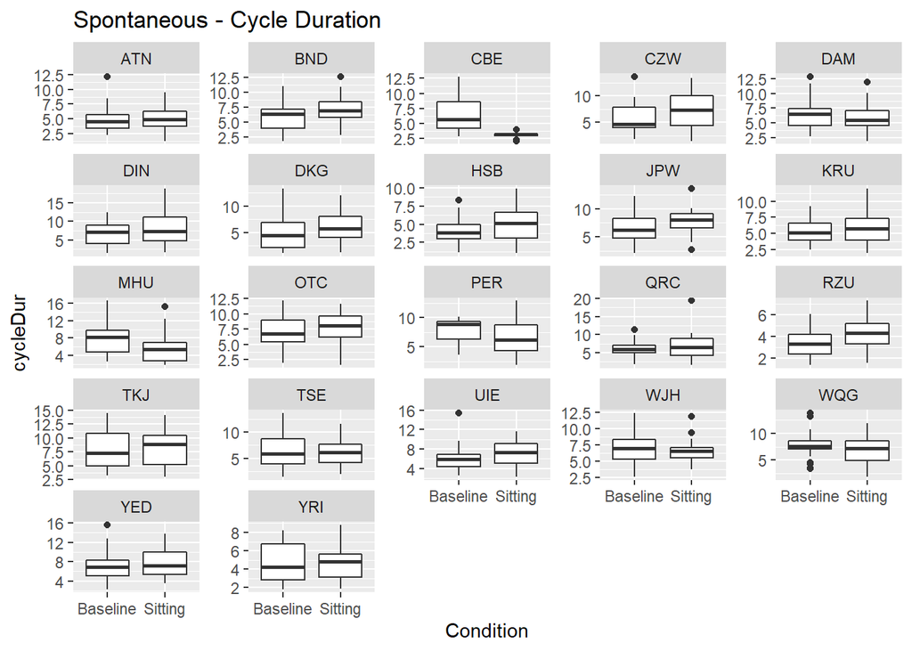

```r
ggplot(dat %>% filter(Condition %in% c("Baseline", "Sitting")), aes(Condition, cycleDur))+
  geom_boxplot()+
  facet_wrap(~Speaker, scales="free_y")+
  ggtitle("Spontaneous - Cycle Duration")
```

```r
ggsave(paste0(folderInd, "Spontaneous-CycleDur-BaselineInteraction.png"), width = 3000, height=3000, units="px")
```

A few participants had longer cycles during Sitting (vs. Baseline), a few the opposite. Most didn’t show much of a difference.

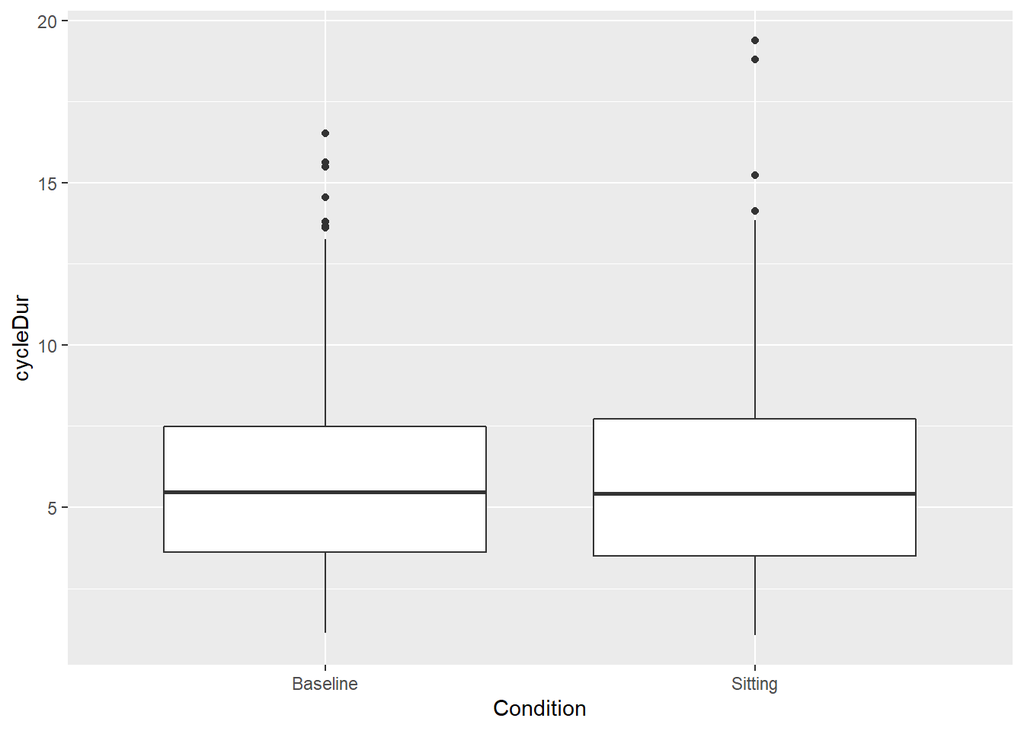

```r
ggplot(dat %>% filter(Condition %in% c("Baseline", "Sitting")), aes(Condition, cycleDur))+
  geom_boxplot()
```

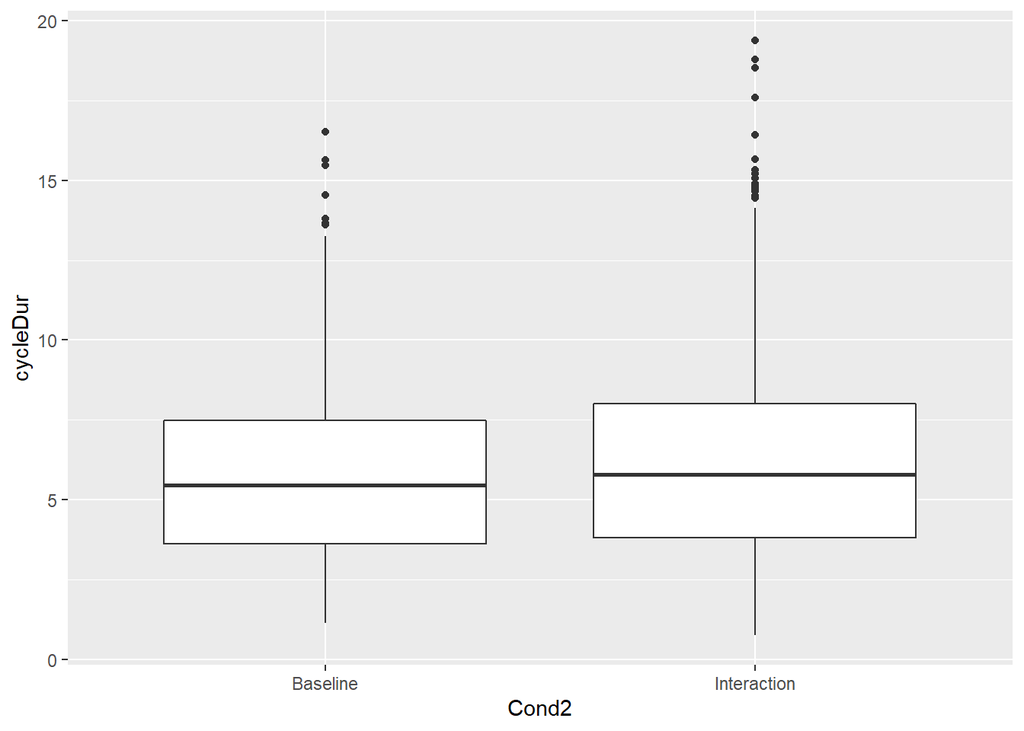

```r
ggplot(dat, aes(Cond2, cycleDur))+
  geom_boxplot()
```

- Cycle duration doesn’t change between Baseline and Sitting or Baseline and Interaction during solo spontaneous speech.

```r
summary(b1 <- lmer(cycleDur ~ Condition + (1+Condition| Speaker), dat %>% filter(Condition %in% c("Baseline", "Sitting"))))
```

```
## Linear mixed model fit by REML ['lmerMod']
## Formula: cycleDur ~ Condition + (1 + Condition | Speaker)
##    Data: dat %>% filter(Condition %in% c("Baseline", "Sitting"))
##
## REML criterion at convergence: 5639.5
##
## Scaled residuals:
##     Min      1Q  Median      3Q     Max
## -2.4274 -0.6819 -0.0850  0.5576  4.8700
##
## Random effects:
##  Groups   Name             Variance Std.Dev. Corr
##  Speaker  (Intercept)      1.2674   1.1258
##           ConditionSitting 0.9754   0.9876   -0.28
##  Residual                  6.6841   2.5854
## Number of obs: 1175, groups:  Speaker, 22
##
## Fixed effects:
##                  Estimate Std. Error t value
## (Intercept)        6.1433     0.2657  23.119
## ConditionSitting   0.1569     0.2644   0.593
##
## Correlation of Fixed Effects:
##             (Intr)
## CondtnSttng -0.388
```

```r
summary(b1a <- lmer(cycleDur ~ Cond2 + (1+Cond2| Speaker), dat))
```

```
## Linear mixed model fit by REML ['lmerMod']
## Formula: cycleDur ~ Cond2 + (1 + Cond2 | Speaker)
##    Data: dat
##
## REML criterion at convergence: 10857.2
##
## Scaled residuals:
##     Min      1Q  Median      3Q     Max
## -2.3816 -0.6936 -0.1063  0.5900  4.6980
##
## Random effects:
##  Groups   Name             Variance Std.Dev. Corr
##  Speaker  (Intercept)      1.2113   1.1006
##           Cond2Interaction 0.6777   0.8232   -0.23
##  Residual                  7.0410   2.6535
## Number of obs: 2249, groups:  Speaker, 22
##
## Fixed effects:
##                  Estimate Std. Error t value
## (Intercept)        6.1255     0.2619  23.392
## Cond2Interaction   0.3450     0.2213   1.559
##
## Correlation of Fixed Effects:
##             (Intr)
## Cnd2Intrctn -0.393
```

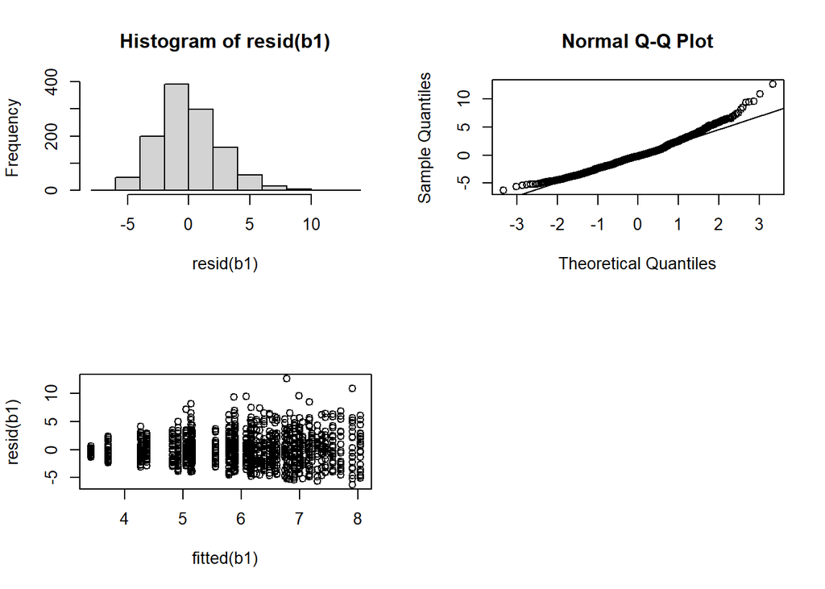

```r
par(mfrow=c(2, 2))
hist(resid(b1))
qqnorm(resid(b1));qqline(resid(b1))
plot(fitted(b1), resid(b1))
```